# assignment-workflow – Data Analytics for Finance

Author

Affiliation

Caspar David Peter

Rotterdam School of Management, Accounting Department

# Data Analytics for Finance

BM17FI · Rotterdam School of Management

Frequently Asked Questions

# Assignment Workflow

This document outlines the workflow for completing the assignments on data analytics for finance. During this course, you will be using an online environment for the assignments for which you only need a recent web browser, JupyterHub. Follow these steps to ensure a smooth process from working on the assignment to submitting it for evaluation.

## Step 1: Access the Assignment

1. Check your (Canvas) email for the login credentials to access [JupyterHub](https://callisto.rsm.nl/hub/login).
2. Log in to JupyterHub using the provided credentials.

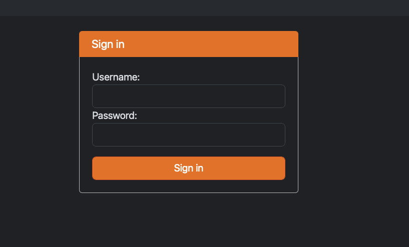

JupytherHub Login

## Step 2: Fetch the Assignment

1. In your JupyterHub environment, navigate to/click on “NBGRADER” -> “List Assignments”.
2. Find the assignment you need to work on and click “Fetch” to download it to your workspace.
3. After fetching, you will see the assignment files in your JupyterHub file browser (left side of your screen). Each assignment will have a folder named after the assignment (e.g., `01-assignment`).
4. Click on the assignment folder to open it.

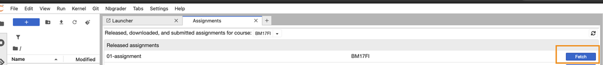

JupytherHub Fetch Assignment

## Step 3: Work on the Assignment

1. Open the assignment notebook (e.g., `01-assignment.ipynb`) by clicking on it.
2. Complete the tasks as specified in the notebook. Make sure to follow any instructions provided and write your code in the designated cells.
3. Save your work frequently by clicking the save icon or using `Ctrl + S`.
4. Do not modify any cells except the ones you are supposed to fill in your code, e.g. ““# YOUR CODE HERE”“.

[figure not shown]

JupytherHub Enter Code

**TipTrouble with Jupyter notebooks?**

If you cannot execute the code in the notebook, you should check the following things:

1. Make sure you are connected to the JupyterLab.
2. Make sure the **kernel** is running. You can check this by looking at the top right corner of the notebook. It should say “Stata” or something similar. If it says “No kernel”, you can select the kernel by clicking on the kernel name and selecting the “State kernel” from the list.
3. If your kernel is running, but you still cannot execute the code, you can try to restart the kernel and clear the output. You can do this by clicking on the kernel tab and selecting “Restart kernel and clear output” from the list. This will restart the kernel and clear the output, and you can try to execute the code again.

   **Important**:
   - After restarting the kernel, you need to re-run all previous cells before the one you want to execute.
   - Restarting the kernel will NOT delete your code or changes in the notebook; it only resets the execution environment.
4. It may also well be that the **server is overloaded**. In that case, please try again later. Typically, the server is less busy in the evenings or during weekends. **Peak times are right before assignment deadlines**. Take this into account when planning your work.

Example of the correct kernel

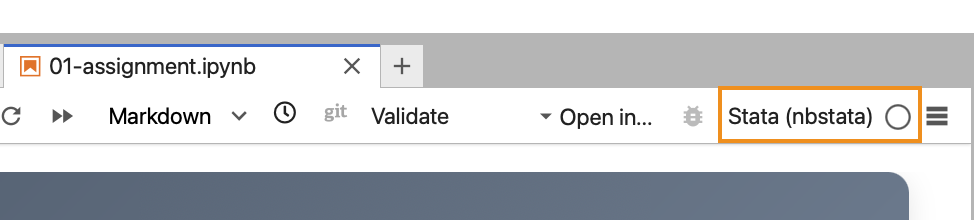

JupytherHub Kernel

Example of restarting the kernel

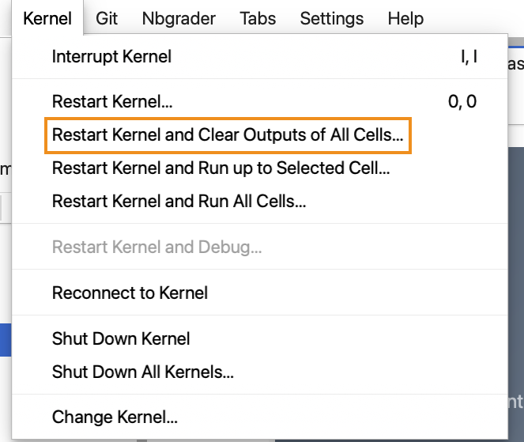

JupytherHub Restart Kernel

## Step 4: Submit the Assignment

1. Once you have completed the assignment, return to “NBGRADER” -> “List Assignments”.
2. You will see a “Submit” button next to the assignment you are working on. Click “Submit” to upload your completed assignment for evaluation.

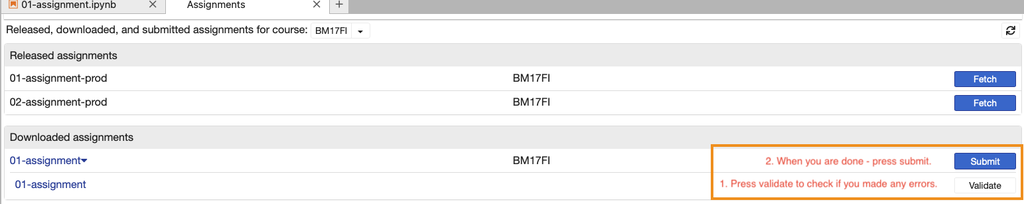

JupytherHub Submit Assignment

**TipBefore You Submit**

- Double-check your work to ensure all required cells are filled out.
- Make sure your code runs without errors.
- Click on the assignment name, e.g. `01-assignment`. You will see another button “Validate”, beow the “Submit” button. Click “Validate” to check if your assignment meets the submission criteria.
- Any failed “test” will be shown. You can fix the issues before submitting. Or submit as is.
- Once you are satisfied with your work, proceed to submit.

## Step 5: Feedback and Grading

1. After submission, your assignment will be graded by the instructor.
2. You will receive feedback regarding your accomplished points through JupyterHub once the grading is complete.
3. To review the feedback, navigate to the assignment folder. In this folder, you will find a file named `feedback.html`. Open this file to see detailed feedback on your assignment. Open it by using a right-click and selecting “Open in new browser tab”. The new tab in the browser will show your feedback.

[figure not shown]

JupytherHub Feedback

**ImportantWhat to Do If You Encounter Issues?**

- If you face any technical issues while working on the assignment(s), contact me (peter@rsm.nl) via email. Make sure to **provide a detailed description of the issue** you are facing, so I can assist you effectively or reach out to the JupyterHub support team if necessary.
- For questions related to the assignment content, feel free to ask during office hours.

Data Analytics for Finance

BM17FI · Academic Year 2025–26

Created by: Caspar David Peter

© 2026 Rotterdam School of Management